# Gene Expression Prediction Challenge 3.0 (expred3.0)

sujet et compte rendu

Chaimaa RIZKI - Florence PITTION BORDIGON - Bilel HEDDIA - EL Hadrami N’DOYE - Ismaïl RAMDÉ - Team D

2021-10-04

# 1 Objectif

1. On cherche à expliquer l’expression du gène ALS2 dans le jeu de données data_train,
2. Pour rédire les valeurs d’expression du gène ALS2 dans le jeu de données data_test.

# 2 Statistiques descriptives

**Le jeu de donnée `data_train`**

```r
data_train <- readRDS(file = "data_train.rds")
data_test <- readRDS(file = "data_test.rds")
head(data_train[,1:6])
```

```
#>           age sex histology     ALS2     ARF5     CD38
#> TEST001 35.20   M astro_ana 10.43222 12.62100 11.72484
#> TEST002 24.67   F astro_nos 11.01653 12.00244 12.14147
#> TEST003 48.39   M oligo_nos 11.31561 12.86240 11.91491
#> TEST004 34.46   M oligo_nos 11.48458 12.56700 11.96411
#> TEST005 38.77   F astro_nos 10.83468 12.62292 12.15143
#> TEST006 45.10   F oligo_nos 11.55177 12.75480 12.73778
```

**Distribution de l’expression de ALS2**

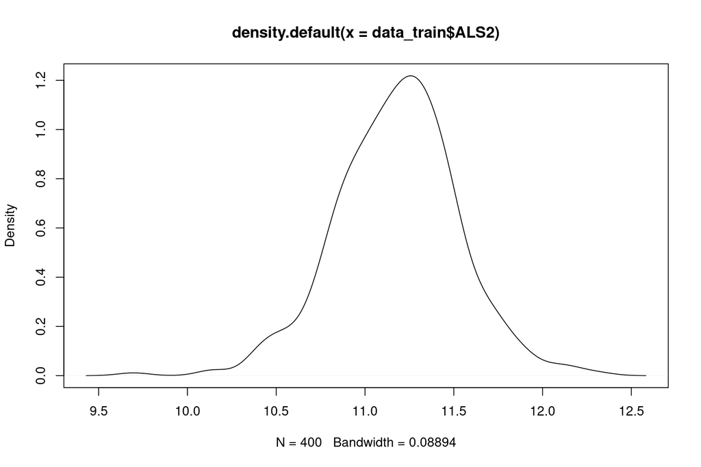

**Distribution du transcriptome dans `data_train`**

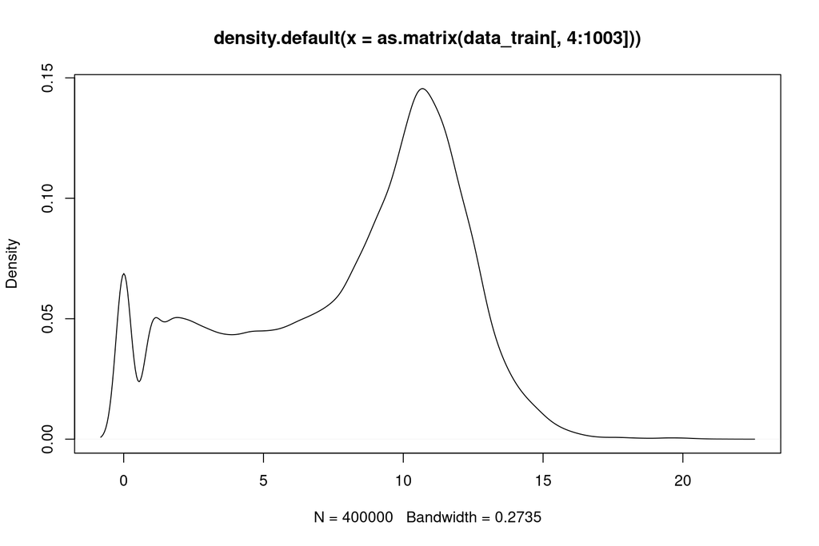

**Distribution du methylome dans `data_train`**

Pas utilisé dans ce TP

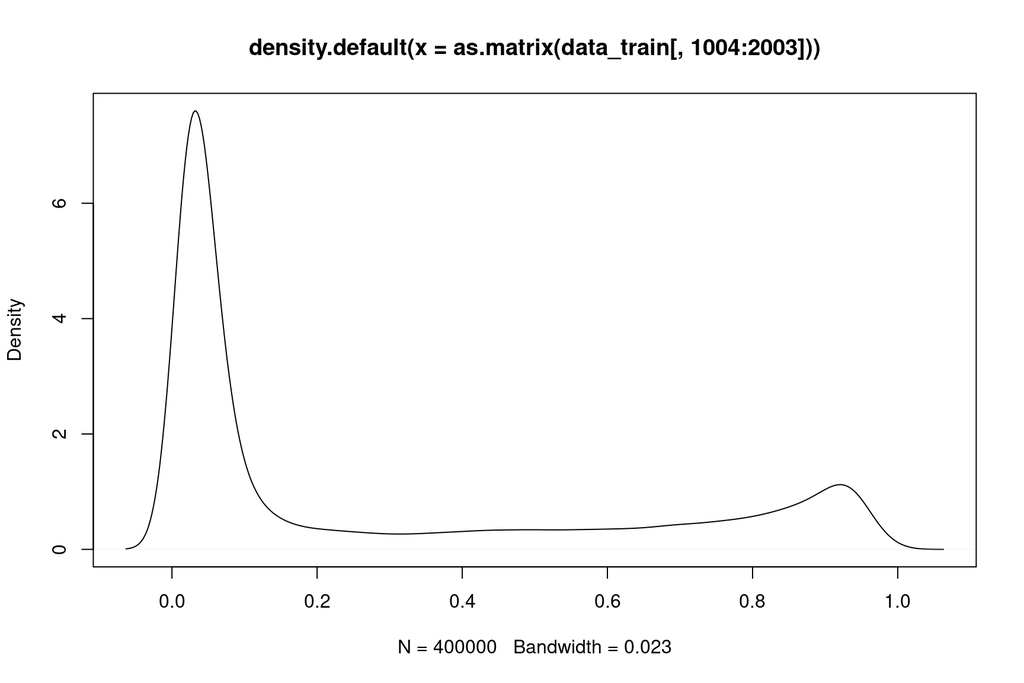

# 3 Method 1 : SIS

La method SIS [Shurely Independant Screening, Zhang HH. J R Stat Soc Series B Stat Methodol. 2008] appliquée au *transcriptome* (définir) consiste à réaliser autant de regressions linéaires simples qu’il y a de variables explicatives (gènes).

*Critères*, pour chaque gène $g$ on calcule le $\beta_{g}$ et la p-valeur $pv_g$ associée.

*Selection de variables*, on selectionne sur le *volcano plot* les gènes qui ont les meilleurs scores, indépendamment les uns des autres.

*Modèle*, on propose un modèle de regression linéaire multiple expliquant l’expression de ALS2.

**Calcul des modèles indépendants**

Pour chaque gènes calculer le $\beta_{gene}$ et la p-valeur associée au modèle $ALS2~gène$, on charactérisera aussi la distribution des résidus.

**Normalité**

Afficher :

- en abscisse les $-log10(p-valeurs)$ des tests de Shapiro-Wilk sur les résidus de chacun des modèles indépendants,
- en ordonée les $-log10(p-valeurs)$ des tests de Student (ou Fisher) associés.

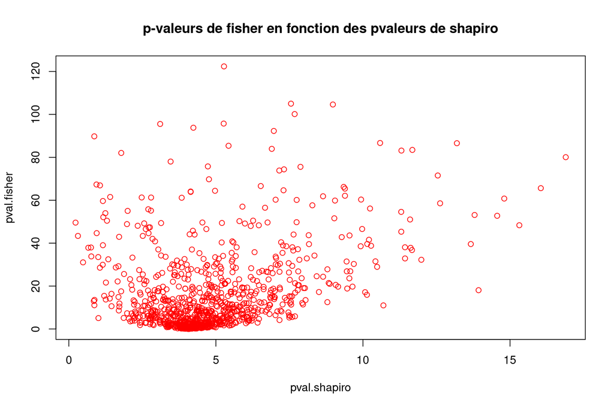

$\underline{\text{Observations et interprétations :}}$

On constate que la majorité des points se concentrent autours de $5$ et le reste des points ont plutôt tendance a se diriger vers le haut et a droite.

**Volcano plot**

Afficher :

- en abscisse les $\beta_{gene}$ des modéles de régression simple pour chaque gène $g$,
- en ordonée les $-log10(p-valeurs)$ des tests de Student (ou Fisher) associés.

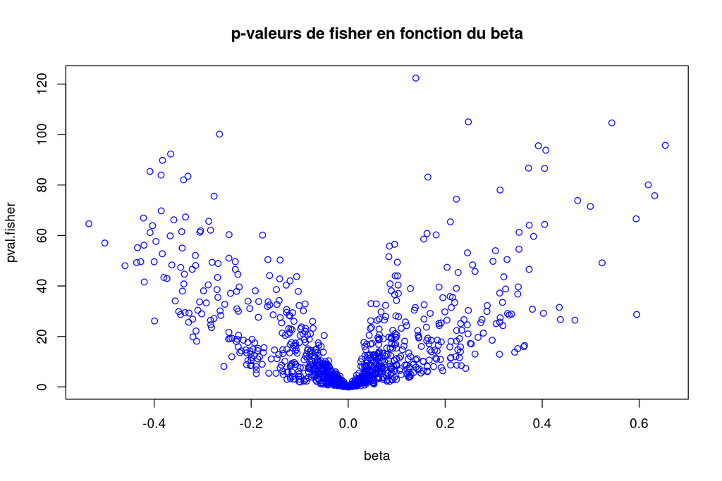

$\underline{\text{Observations et interprétations:}}$

Nous remarquons ici que, les points sont dispersés autours de l’origine avec une forte concentration au niveau des celle-ci. Cette distribution indique une corrélation négative des points avant l’origine suivie d’une corrélation positive.

## 3.1 Méthodologie:

Avant d’appliquer la méthode de sélection des variables, nous commencerons d’abords par trier les p-valeurs obtenues a l’issue du test de fisher par ordre croissant associées a leurs gènes. Ensuite nous choisirons les n premiers gènes. Enfin nous appliquerons la sélection des variables sur ces n gènes.

**Sélection de variables**

La méthode choisie est stepAIC.

Le critère AIC est défini par :

$$AIC = - 2 ln(\mathcal{L}) + 2p$$
avec :

- $\mathcal{L}$ le maximum de la fonction de vraisemblance
- $n$ le nombre d’observations
- $p$ le nombre de paramètres

La formulation analystique de notre modèle:

$Y_{ALS2}=\beta_{0}+\beta_{1}X_{ARF5}+\dots+\beta_{k}X_{k}+\dots+\beta_{p}X_{IDH3G}+\epsilon$

Où la variable expliquée $Y_{ALS2}$ est influencée de manière linéaire par les variables explicatives $X_{ARF5},X_{k}, \dots, X_{IDH3G}$. $\epsilon$ est l’erreur résiduelle,$\beta_{0}$ l’intercepte ou constante de régression et $\beta_{i}$ l’effet du ième gene sur la variable $Y_{ALS2}$.

**Exemple de regression lineaire multiple**

lm(ALS2~ARF5+CD38,data_train)

Dans cette section on cherche a déterminer les gènes qui contribuent au plus a expliquer le gène “ALS2”.

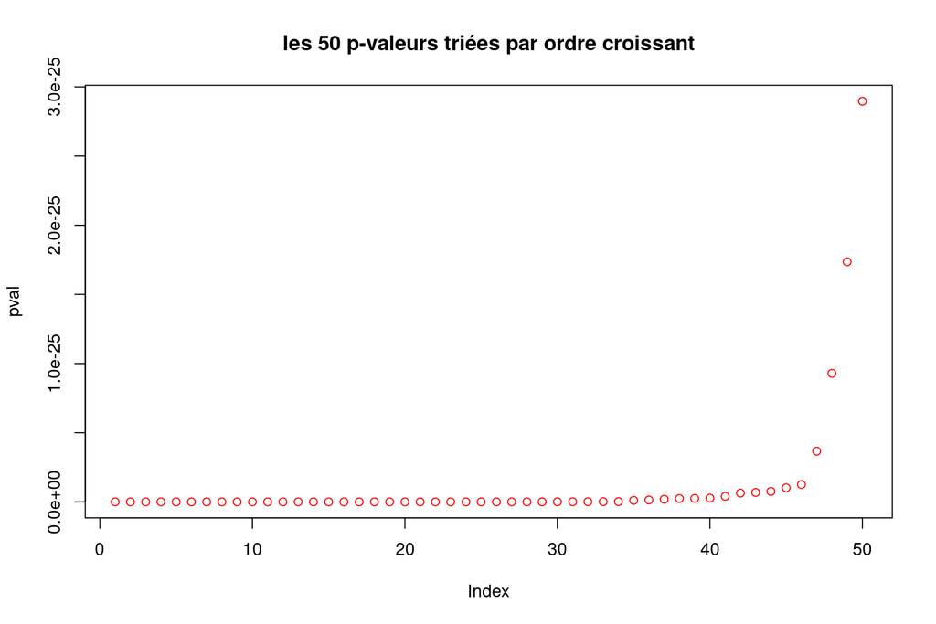

Remarquons que les p-valeurs restent constantes de 0 jusqu’à 40. On peut donc choisir les dix premières pour appliquer une sélection.

**la methode stepAIC**

**Matrice de scatterplot**

```
#> loading package quantable
```

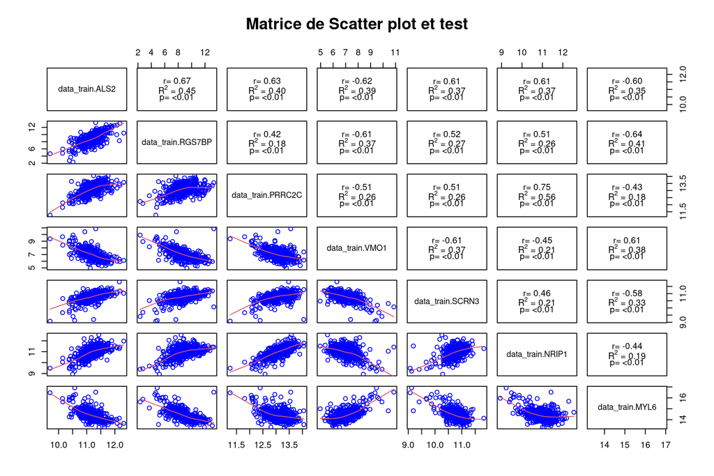

Cette matrice de corrélation confirme les différentes corrélations entre la a expliquer et les variables sélectionnées a partir de la méthode stepAIC. Cela se laisse voir au travers des formes allongées des nuages de points.

**Prédiction**

# 4 Method 2 : ACP

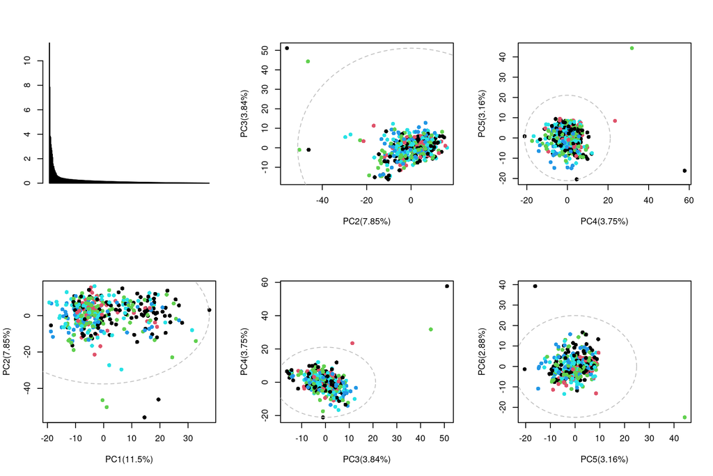

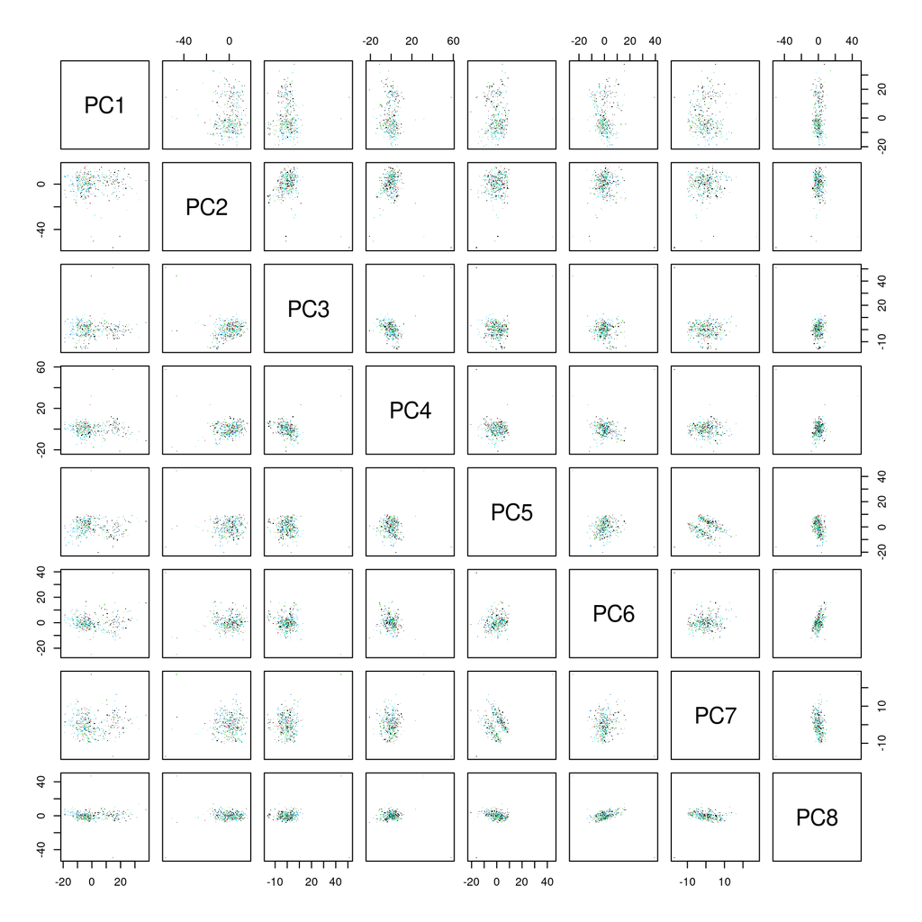